# Laboratorio 2 - Procesos de Poisson

### Carolina Crisci, Gonzalo Perera, Angel Segura

# Introducción

En este LAB simularemos y veremos algunas propiedades de los procesos de Poisson vistos en el teórico.

Con el abordaje de los Procesos de Poisson estudiamos la ocurrencia de eventos en el tiempo o en el espacio. En el caso de variables continuas, fijamos un valor umbral y modelamos el número de veces que se supera dicho valor en un período de tiempo dado (*High level excedance*).

Recordemos que en la primera parte del curso, mediante el enfoque de Fisher-Tippett-Gnedenko basado en las distribuciones extremales, nos ocupamos de modelar los valores máximos de cierto fenómeno, es decir, para un período de tiempo dado, considerábamos el valor máximo de variables aleatorias *iid*. Con los Procesos de Poisson (PP) no nos enfocamos en “lo peor” o lo más grande, sino, en eventos extremos o inusuales que superan cierto umbral definido por el/la investigador/a. Además nos permite trabajar con la ocurrencia de eventos (discretos).

Ejemplos:

¿Cuántas veces la velocidad del viento proveniente del cuadrante SO supera los 60 km/h en el lapso de un mes?

¿Cuántas veces se supera la entrada de 15 pacientes por hora en una sala de emergencias?

El pasaje de animales de una especie ante una camara de monitoreo.

Número de clientes en cola de sistemas de cajeros (en un super).

¿Otros ejemplos?

Comenzaremos realizando un repaso de las distribuciones de Poisson y Exponencial ya que son fundamentales para entender los Procesos de Poisson. Luego continuaremos trabajando con los procesos de Poisson en este orden: Procesos de Poisson simples (PP), Procesos de Poisson Compuestos (PPC) y Procesos de Poisson No Homogéneos (PPNH).

## Distribucion de Poisson

La distribución de Poisson es una distribución de probabilidad discreta que expresa la probabilidad de que ocurra un determinado número de eventos durante cierto período de tiempo.

Sea $\lambda > 0$ y $X$ una variable aleatoria discreta, si $X$ tiene una distribución de Poisson con parámetro $\lambda$, entonces notaremos $X \sim {\sf Poisson}(\lambda)$

Si $X \sim {\sf Poisson}(\lambda)$ su función de probabilidad es:

$P[X=k] = \frac{\ e^{-\lambda}\lambda^{k}}{\ k!}$

donde $k=0,1,2,...$ es el número de ocurrencias del evento o fenómeno.

El parámetro $\lambda$ representa el número de veces que se espera que ocurra el fenómeno durante un intervalo dado.

Tanto el Valor Esperado como la Varianza de una variable aleatoria $X$ con distribución de Poisson son $E(X)=\lambda$ y $Var(X)=\lambda$ respectivamente.

Simulemos en R la función de probabilidad de una variable aleatoria $X \sim {\sf Poisson}(5)$

```r
lmbd=5 #parámetro lambda
x=0:50 # vector de cuantiles
p5=dpois(x,lmbd)
p5
```

```
##  [1] 6.737947e-03 3.368973e-02 8.422434e-02 1.403739e-01 1.754674e-01
##  [6] 1.754674e-01 1.462228e-01 1.044449e-01 6.527804e-02 3.626558e-02
## [11] 1.813279e-02 8.242177e-03 3.434240e-03 1.320862e-03 4.717363e-04
## [16] 1.572454e-04 4.913920e-05 1.445271e-05 4.014640e-06 1.056484e-06
## [21] 2.641211e-07 6.288597e-08 1.429227e-08 3.107014e-09 6.472947e-10
## [26] 1.294589e-10 2.489595e-11 4.610361e-12 8.232787e-13 1.419446e-13
## [31] 2.365743e-14 3.815715e-15 5.962055e-16 9.033417e-17 1.328444e-17
## [36] 1.897777e-18 2.635801e-19 3.561893e-20 4.686701e-21 6.008592e-22
## [41] 7.510739e-23 9.159438e-24 1.090409e-24 1.267918e-25 1.440816e-26
## [46] 1.600906e-27 1.740116e-28 1.851187e-29 1.928320e-30 1.967673e-31
## [51] 1.967673e-32
```

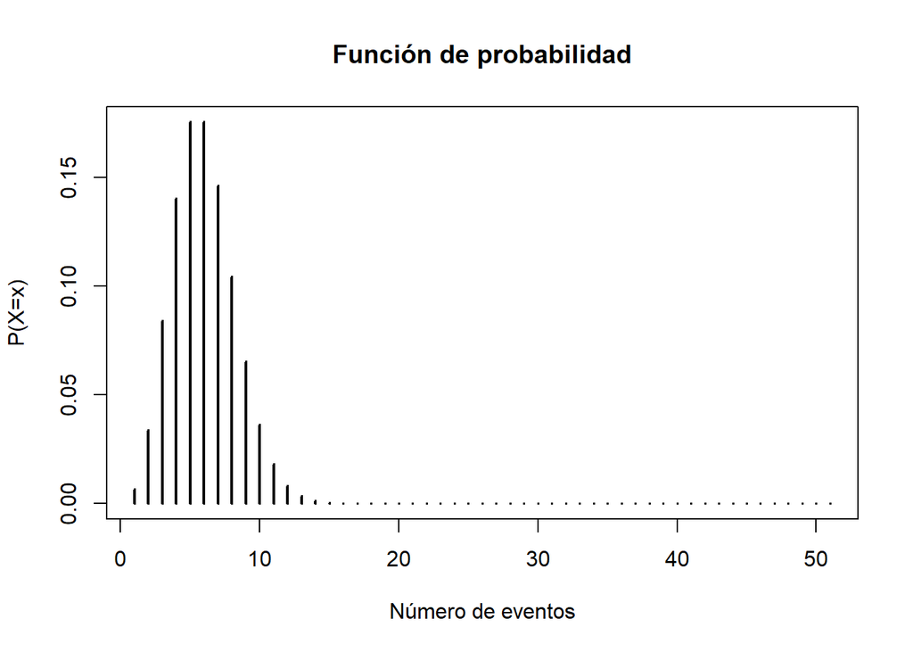

```r
plot(p5, type = "h", lwd = 2,
     main = "Función de probabilidad", ylab="P(X=x)",xlab="Número de eventos")
```

Veamos el comportamiento de la función de probabilidad considerando diferentes lambdas

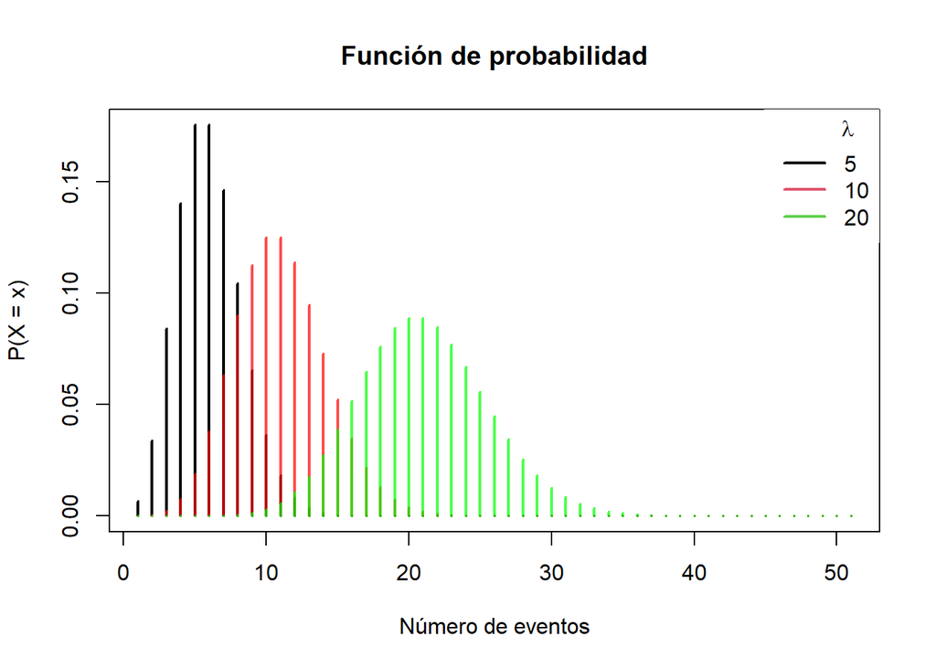

```r
lmbd10=10
p10=dpois(x,lmbd10)

lmbd20=20
p20=dpois(x,lmbd20)

plot(p5, type = "h", lwd = 2,
     main = "Función de probabilidad",
     ylab = "P(X = x)", xlab = "Número de eventos")
lines(p10, type = "h", lwd = 2, col = rgb(1,0,0, 0.7))
lines(p20, type = "h", lwd = 2, col = rgb(0, 1, 0, 0.7))

legend("topright", legend = c("5", "10", "20"),
       title = expression(lambda), title.adj = 0.75,
       lty = 1, col = 1:3, lwd = 2, box.lty = 0)
```

Considerando una $X \sim {\sf Poisson}(5)$

¿Cuál es la probabilidad de observar más de cinco eventos en un intervalo de tiempo?

```r
ppois(5,lambda=5,lower.tail=FALSE)
```

```
## [1] 0.3840393
```

¿Qué valor toma la probabilidad de observar más de cinco eventos en un intervalo de tiempo si consideramos que la variable $X \sim {\sf Poisson}(10)$?

```r
ppois(5,lambda=10,lower.tail=FALSE)
```

```
## [1] 0.932914
```

¿Cuál la probabilidad de obtener exactamente 5 eventos? Consideramos una $X \sim {\sf Poisson}(5)$

```r
p_menori4=ppois(4,lambda=5) #lower.tail=T
p_mayor5=ppois(5,lambda=5,lower.tail = F) #lower.tail=T
1-p_menori4-p_mayor5
```

```
## [1] 0.1754674
```

La siguiente función es útil para simular variables aleatórias con distribución de Poisson.

```r
set.seed(71)
rpois(70,lambda=3) #genero 70 números aleatorios de una variable X con distribución de Poisson de parámetro lambda=3
```

```
##  [1] 2 3 2 2 2 6 4 5 2 3 1 4 1 4 5 4 1 4 5 6 3 2 4 2 1 3 2 2 2 5 1 3 4 1 4 5 3 2
## [39] 3 0 2 3 0 4 2 3 3 1 0 5 0 1 3 3 6 8 3 3 4 1 4 2 1 1 2 1 3 5 3 0
```

Dicha variable podría representar por ejemplo:

Número de accidentes de tránsito en períodos de una semana

Número de pasajes de autos en un cruce de calles determinado por minuto

Número de cirugías de urgnecia en cierto centro de salud por semana

Número de rachas de viento de más de 10 s de duración que superen 80 km/h en período de un mes

Etc.

Etc.

## Distribucion Exponencial

La distribución exponencial es una distribución continua que se utiliza para modelar tiempos de espera para la ocurrencia de un cierto evento. Dicho de otro modo, es una distribución que modela el tiempo (o espacio) entre dos eventos de un proceso de Poisson cuando los eventos ocurren de manera independiente y a una tasa constante.

Una variable aleatoria continua tiene una distribución exponencial con parámetro $\lambda$ $>$ $0$ ($X \sim {\sf Exp}(\lambda)$) si su función de densidad es:

$f_x (x) = \lambda e^{-\lambda x}$ para $x \ge 0$

El Valor Esperado de una variable aleatoria continua $X$ con distribución de Exponencial es $E(X)=1/\lambda$ y la Varianza $Var(X)=1/\lambda^2$

Simulemos y grafiquemos en R la función de densidad de una variable aleatoria $X$ con distribución *Exponencial* considerando distintos $\lambda$.

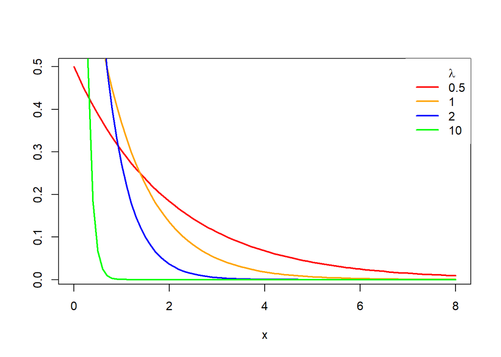

```r
x <- seq(0, 8, 0.1)
# lambda = 0.5
plot(x, dexp(x, rate =0.5), type = "l",
     ylab = "", lwd = 2, col = "red")

# lambda = 1
lines(x, dexp(x, rate = 1),
     ylab = "", lwd = 2, col = "orange")

# lambda = 2
lines(x, dexp(x, rate = 2), col = "blue", lty = 1, lwd = 2)

# lambda = 10
lines(x, dexp(x, rate = 10), col = "green", lty = 1, lwd = 2)


# Leyenda
legend("topright", c(expression(paste(lambda)),"0.5","1","2","10"),
       lty = c(0, 1, 1,1,1), col = c(NULL, "green","red","orange","blue"), box.lty = 0, lwd = 2)
```

```r
set.seed(71)
rexp(70,rate=3) #genero 70 números aleatorios de una variable X con distribución Exponencial de parámetro lambda=3
```

```
##  [1] 0.34161981 0.03673591 0.33420901 0.53513766 0.10780931 0.07809687
##  [7] 0.72590899 0.17793893 0.22809202 0.18449957 0.48563854 0.20395740
## [13] 0.14214603 0.28103122 0.13883231 0.50670574 0.45335732 0.33881018
## [19] 0.29643503 0.01212275 0.19761962 1.02970164 0.47119800 0.39963671
## [25] 0.07961654 0.98596914 0.10640556 0.43789230 0.09225297 0.03134409
## [31] 0.69863177 0.46297981 0.06909505 0.00266523 0.10998945 0.08472040
## [37] 0.10514211 0.62857246 0.10375860 0.47428787 0.33857677 0.61654458
## [43] 0.01855822 0.21054388 0.23962139 0.13853652 0.14485412 0.05467695
## [49] 0.06864550 0.20505334 0.46528114 0.55786762 0.32665841 0.82013817
## [55] 0.09163054 0.54620434 0.76922357 0.25175766 0.08412288 0.44317290
## [61] 0.41080195 0.33185927 0.80157849 0.13601630 0.25729766 0.13092189
## [67] 0.22726978 0.24763711 0.24002005 0.25742620
```

## Procesos de Poisson

De modo general, podemos decir que un Proceso de Poisson es un proceso estocástico que registra la ocurrencia de sucesos en el tiempo.

### Proceso de Poisson simple (PP($\lambda$))

Si $N$ es un proceso de conteo y $\lambda$ $>$ $0$ diremos que $N$ es un Proceso de Poisson de parámetro $\lambda$ ($N$ es PP($\lambda$)) si se cumple:

1. Para todo intervalo $J$ de los reales positivos, $N(J)$ es una variable aleatoria que tiene distribución de Poisson de parámetro $\lambda *longitud(J)$.
2. Si $J$, $L$, $M$….es una cantidad arbitraria de intervalos de reales positivos **DISJUNTOS** entonces $N(J)$, $N(L)$, $N(M)$ son variables aleatorias independientes.

Simulemos un Proceso de Poisson simple

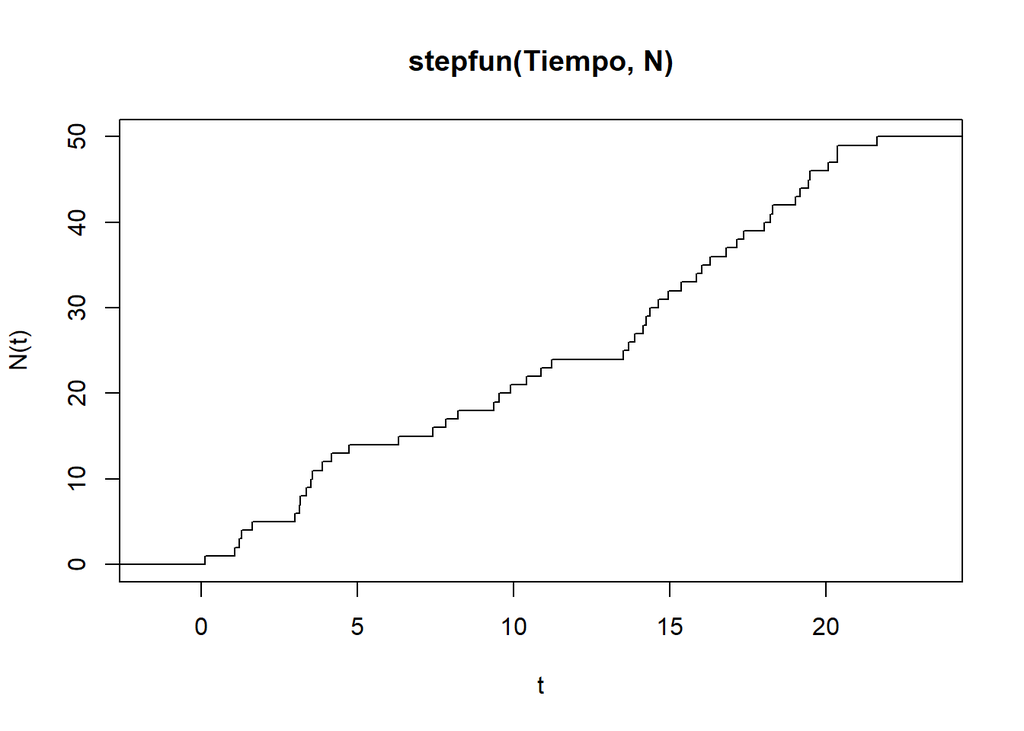

```r
k = 50  #defino k, número de eventos
lambda = 2 #defino lambda
set.seed(15)
expon=rexp(k,rate=lambda) #genero 50 números aleatorios de una variable X con distribución Exponencial de parámetro lambda=2

Tiempo = cumsum(expon) #calculo las sumas acumuladas de dichas observaciones lo que se va a corresponder con los tiempos de ocurrencia de los eventos

N = 0:k

#grafico el tiempo en función del número de eventos
plot(stepfun(Tiempo,N),do.points=F,xlab="t",ylab="N(t)")
```

Si bien aquí ya sabemos cual es nuestro lambda pues nuestros datos son generados a partir de una simulación en la cual definimos $\lambda=2$, hagamos el ejercicio de estimar lambda ($\hat \lambda$) manualmente a partir de los datos simulados.

Recordemos que los tiempos interevento tienen media $1/\lambda$ ya que esta variable se distribuye según una exponencial de parámetro $\lambda$.

Debemos en primer lugar, a partir de la variable Tiempo, calcular los tiempos interevento, esto lo hacemos restando a cada tiempo el tiempo previo. En R esto lo hacemos fácilmente con la función *diff()*.

```r
Dif_tiempo=diff(Tiempo)
Dif_tiempo
```

```
##  [1] 0.973322890 0.127217424 0.088018729 0.331429021 1.377075686 0.146150910
##  [7] 0.009090392 0.206628568 0.155072176 0.048931711 0.303727399 0.293345952
## [13] 0.561699827 1.582367033 1.091146698 0.435553825 0.387287635 1.144275468
## [19] 0.158533380 0.364811196 0.534129738 0.461039446 0.343898076 2.275275105
## [25] 0.166700071 0.214119947 0.268503796 0.085963634 0.127862090 0.276130319
## [31] 0.317804436 0.393624199 0.490166232 0.173936632 0.274178611 0.508408451
## [37] 0.333017880 0.235766450 0.656200084 0.180911102 0.090463172 0.725742209
## [43] 0.141289949 0.264990433 0.056251295 0.581560194 0.298936418 0.004207106
## [49] 1.271231635
```

A partir de las diferencias, calculamos la media y computamos su inverso para obtener $\lambda$.

```r
mean(Dif_tiempo)
```

```
## [1] 0.4395509
```

```r
lambda1=1/mean(Dif_tiempo)
lambda1
```

```
## [1] 2.275049
```

Observamos que el valor calculado de $\lambda$ se encuentra bastante próximo a dos (valor teórico), a medida que aumentamos el número de datos (eventos) se aproximará cada vez más a este valor.

Probémoslo aumentando el número de eventos que registro. Tengamos en cuenta que en la vida real, para aumentar el número de registros deberíamos incrementar el esfuerzo de muestreo (mayor tiempo registrando el proceso).

```r
k2 = 100000  #defino k, número de eventos
set.seed(122)
expon2=rexp(k2,rate=lambda)
Tiempo2 = cumsum(expon2) #calculo las sumas acumuladas de dichas observaciones lo que se va a corresponder con los tiempos de ocurrencia de los eventos

Dif_tiempo2=diff(Tiempo2)

mean(Dif_tiempo2)
```

```
## [1] 0.5004787
```

```r
lambda2=1/mean(Dif_tiempo2)
lambda2
```

```
## [1] 1.998087
```

Gracias a la ley de los grandes números tenemos otra forma de estimar $\lambda$ cuando $t$ es grande (pag.64 del teórico):

$N(0,t)/t$

Es decir, el número total de eventos observados en el período (0,t) sobre el tiempo total de observación.

```r
k2/max(Tiempo2)
```

```
## [1] 1.998104
```

Nuevamente, asumiendo que desconocemos la estructura de los datos simulados, apliquemos el test de Lilliefors para determinar si los tiempos interevento siguen una distribución *Exponencial*. Recordemos que esta es una condición necesaria para asumir que estamos frente a un Proceso de Poisson simple (PP).

Usaremos la función *LcKS* del paquete {KScorrect}:

```r
#install.packages("KScorrect")
require(KScorrect)
TestLillie=LcKS(Dif_tiempo, "pexp", nreps = 4999)
TestLillie$p.value
```

```
## [1] 0.3584
```

No rechazo $H_0$ por lo que puedo asumir razonablemente que mis tiempos intereventos siguen una distribución *Exponencial* (cosa que en realidad ya sabíamos).

### Proceso de Poisson Compuesto (PPC ($\lambda,~G$))

El Proceso de Poisson Compuesto (PPC) surge a partir de la necesidad de modelar fenómenos en donde los eventos no ocurren necesariamente uno a la vez, si no que pueden ocurrir más de un evento simultáneamente.

Repasemos la definición de este tipo de proceso.

Si $N$ es un Proceso de Poisson de parámetro $\lambda$ $>$ $0$, $G$ es una distribución de probabilidad en los naturales (1,2,3,…), consideramos $S_1,S_2,S_n,...iid$ con distribución $G$ y construímos un nuevo proceso de conteo $M$ de la forma siguiente:

Cuando $N$ tiene su primer evento, $M$ tiene $S_1$ eventos simultáneos; Cuando $N$ tiene su segundo evento, $M$ tiene $S_2$ eventos simultáneos…..(y así sucesivamente)

Decimos que M es un Proceso de Poisson Compuesto de parámetro $\lambda$ $>$ $0$ y distribución de eventos $G$ ($M$ es $PPC( \lambda,~G)$).

En este tipo de proceso el tiempo medio interevento sigue siendo $1/\lambda$, pero la tasa de incidencia media de eventos ahora es $E(X)=\lambda ~E(G)$

Consideremos ahora los tiempos del primer ejemplo de PP y adjudiquemos a cada tiempo un número de eventos. Para esto último, a fin de simplificar, simularemos una distribución de Poisson y le sumaremos uno para evitar los ceros.

```r
nro_eventos=rpois(50,1)+1
PPC=cbind(Tiempo,nro_eventos)
colnames(PPC)=c("Tiempo","Orden")
head(PPC,10)
```

```
##         Tiempo Orden
##  [1,] 0.102114     2
##  [2,] 1.075437     1
##  [3,] 1.202654     3
##  [4,] 1.290673     2
##  [5,] 1.622102     1
##  [6,] 2.999178     1
##  [7,] 3.145329     1
##  [8,] 3.154419     1
##  [9,] 3.361048     1
## [10,] 3.516120     1
```

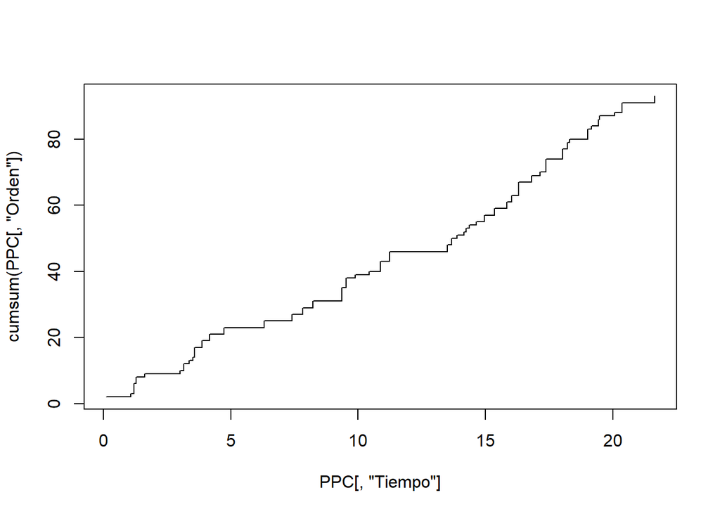

```r
plot(PPC[,"Tiempo"],cumsum(PPC[,"Orden"]), type="s")
```

Observamos que la gráfica muestras escalones o “saltos” que no son siempre unitarios, lo que nos debería inducir a pensar que estamos frente a un PPC. Luego estimamos de forma empírica la función $G$ como las frecuencias relativas de los *Ordenes*.

```r
# Estimo la función G a partir de las frecuencias relativas.
G<- table(PPC[,"Orden"])/sum(table(PPC[,"Orden"]))
G
```

```
##
##    1    2    3    4
## 0.40 0.40 0.14 0.06
```

Podemos decir que estamos ante un $PPC(\lambda=2, ~G)$.

Podríamos suponer que estos datos corresponden a los tiempos en que cierta variable supera determinado umbral, y en los casos en que este umbral es superado en “cluster” por más de un evento, se registra el número de eventos que ocurren juntos (Orden).

En este ejemplo, si nos interesa saber cual es el número de eventos promedio de Orden 4 por unidad de tiempo, debemos utilizar la estimación de $\lambda= 2$ multiplicado por la probabilidad de de tener un evento de Orden 4 ($G(4)=0.06$) que nos queda $0.06*2= 0.12$.

Los tiempos intereventos los tenemos calculados de la sección de PP (Dif_Tiempo) así como su promedio y a partir de allí el valor de lambda (que en realidad sabíamos previamente que tenía un valor porque simulamos los datos). Sabemos a su vez que el test de Lilliefors no rechaza la distribución *Exponencial*.

Algo que no hicimos previamente y que es importante, es evaluar los tiempos intereventos mediante test de aleatoriedad para determinar que los datos sean *iid*. Para realizar los test de aleatoriedad utilizaremos el paquete {randtest} que tiene una batería de pruebas de aleatoriedad. Porbaremos varias. Si todas retienen H0 nos quedamos tranquilos de que los datos son iid.

```r
#install.packages("randtests")
require(randtests)
runs.test(Dif_tiempo)
```

```
##
##  Runs Test
##
## data:  Dif_tiempo
## statistic = -1.1672, runs = 21, n1 = 24, n2 = 24, n = 48, p-value =
## 0.2431
## alternative hypothesis: nonrandomness
```

```r
cox.stuart.test(Dif_tiempo)
```

```
##
##  Cox Stuart test
##
## data:  Dif_tiempo
## statistic = 11, n = 24, p-value = 0.8388
## alternative hypothesis: non randomness
```

```r
turning.point.test(Dif_tiempo)
```

```
##
##  Turning Point Test
##
## data:  Dif_tiempo
## statistic = -0.80561, n = 49, p-value = 0.4205
## alternative hypothesis: non randomness
```

Los distintos tests de rachas utilizados indican que podemos retener la hipótesis nula, es decir, podemos asumir que los datos son *iid*.

### Procesos de Poisson No Homogéneos (PPNH)

Un Proceso de Poisson No Homogéneo (PPNH) es un proceso en que la tasa de ocurrencia de eventos depende el tiempo. Este tipo de procesos pueden ser, en muchos casos, más realistas que los PP y PPC. Ejemplos de aplicación de PPNH son:

Modelar la llegada de más de cierto número de turistas por mes: claramente habrá meses con alto número de turistas (temporada alta) y meses con menor arribo de turistas (temporada baja).

Modelar el número de retiros de dinero en cajeros automáticos en los días del mes.

¿Otros ejemplos?

Retomando la definición del teórico:

Si N es un proceso de conteo y m es una medida que NO puede expresarse como una constante por la longitud, diremos que N es un Proceso de Poisson No Homogéneo de medida $m$ (y abreviaremos N es $PPNH(m)$) si se cumple:

1. Para todo intervalo J de los reales positivos, N(J) es una variable aleatoria que tiene distribución de Poisson de parámetro m(J).
2. Si J, L, M…..es una cantidad arbitraria de intervalos positivos DISJUNTOS, entonces N(J), N(L), N(M),……son variables aleatorias independientes.

Para dejar en claro la diferencia entre los PPNH y los PPC (o el simple PP), recordemos que, en los PPC, los tiempos intereventos son exponenciales de parámetro $\lambda >0$ e *iid*. Si N es un PPNH y T1 es el tiempo del primer evento, la distribución de T1 no es exponencial.

```r
library(IHSEP)
set.seed(69)
tms1 <- simPois(int = function(x) 0.1, cens = 1000) #PP simple con lambda=0.1

T1<-diff(tms1)

#a modo de ejercicio estimo lambda
1/mean(T1) # Lambda = 0.1
```

```
## [1] 0.117381
```

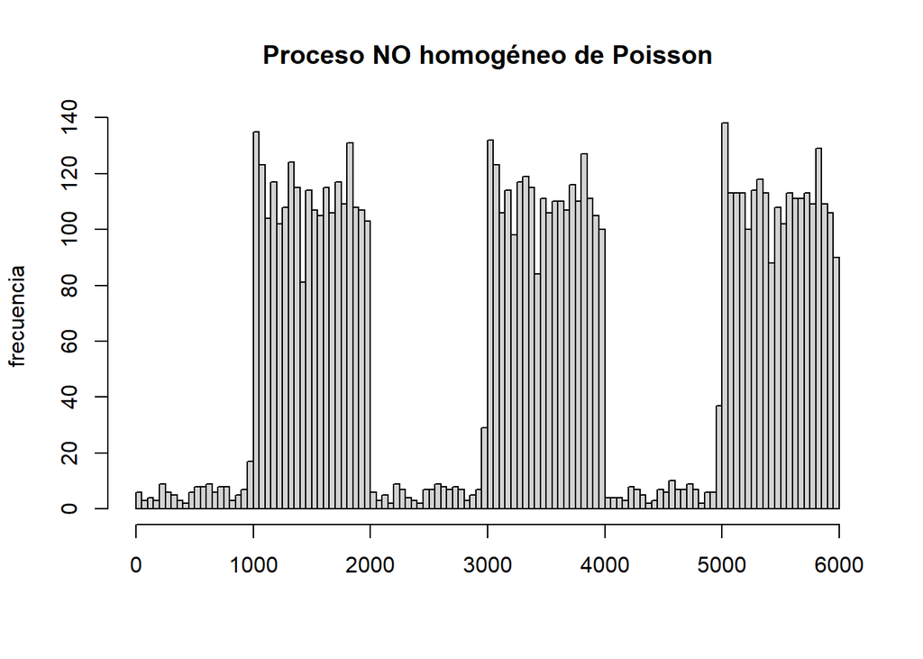

```r
tms2<- simPois(int = function(x) 2, cens = 1000)
#PP simple con lambda=2
T2<-diff(tms2) # Equivalente a T del teórico (Tiempos inter eventos)

Dif_tiempo_NH<- c(T1,T2,T1,T2,T1,T2)

PPNH<- cumsum(Dif_tiempo_NH)

## Visualicemos la cantidad de eventos
hist(PPNH, breaks = 100, main = "Proceso NO homogéneo de Poisson", xlab = "", ylab = "frecuencia")
```

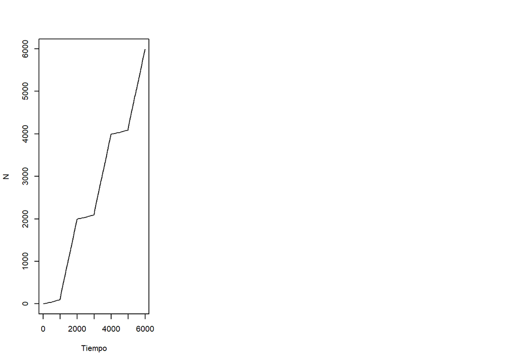

```r
x<-seq(1, max(PPNH), length=length(PPNH))
par(mfrow=c(1,3))
plot(PPNH,x, type="s",ylab="N",xlab="Tiempo")
```

Vale aclarar que esta función también es útil para simular PPNH directamente si se incluye en la misma una función de intensidad.

Tal como venimos haciendo, asumiendo que no conocemos la estructura de los datos, realizaremos test de aleatoriedad y de Lilliefors para determinar qué tipo de proceso siguen nuestros datos.

¿Qué esperamos encontrar?

Aleatoriedad:

```r
#install.packages("randtests")
require(randtests)
runs.test(Dif_tiempo_NH)
```

```
##
##  Runs Test
##
## data:  Dif_tiempo_NH
## statistic = -3.1642, runs = 3402, n1 = 3534, n2 = 3534, n = 7068,
## p-value = 0.001555
## alternative hypothesis: nonrandomness
```

```r
cox.stuart.test(Dif_tiempo_NH)
```

```
##
##  Cox Stuart test
##
## data:  Dif_tiempo_NH
## statistic = 1712, n = 3535, p-value = 0.06428
## alternative hypothesis: non randomness
```

```r
turning.point.test(Dif_tiempo_NH)
```

```
##
##  Turning Point Test
##
## data:  Dif_tiempo_NH
## statistic = 1.8994, n = 7071, p-value = 0.05752
## alternative hypothesis: non randomness
```

```r
#Ajuste a la exponencial de tiempos intereventos
TestLillie=LcKS(Dif_tiempo_NH, "pexp", nreps = 4999)
TestLillie$p.value # devuelve el valor de P
```

```
## [1] 2e-04
```

Otro paquete a explorar para trabajar con PPNH: NHPoisson.

### Ejercicio

Con la serie de datos enviada, que se basa en los tiempos de los registros de utilizacion de un cajero automático, por favor responda:

1. Determinar si es un PP o un PPNH
2. Calcular la tasa de incidencia ($\lambda$) y el tiempo promedio intereventos (si es PPNH recuerde hacerlo para cada segmento).
3. Evalúe si los tiempos intereventos son *iid*